# Exploration of the Weight Lifting Exercises Dataset

Kinga

Wednesday, February 11, 2015

## Getting the Data

The data source for this project is from: http://groupware.les.inf.puc-rio.br/har.

Reading in the training dataset that was downloaded from https://d396qusza40orc.cloudfront.net/predmachlearn/pml-training.csv:

```r
training <- read.csv("pml-training.csv")
attach(training) #attaching data frame to reduce the length of the variable names associated to it.
```

## Preprocessing the Data

The first 7 variables in the training data set are:

X, user_name, raw_timestamp_part_1, raw_timestamp_part_2, cvtd_timestamp, new_window, num_window,

I removed these from the data set since they were not relevant towards predicting “classe”. The removed variables included the time stamp ones as well, since I did not inted to do a time series analysis.

```r
training <- training[,-c(1,2,3,4,5,6,7)]
```

Next, I removed all the columns with missing values from the dataset:

```r
training <-training[,colSums(is.na(training))==0]
```

Then, I found all the columns that are factors, while ignoring the last column which was the response variable “classe.”

```r
col_names <- c()
n <- ncol(training)-1
for (i in 1:n) {
     if (is.factor(training[,i])){
             col_names <- c(col_names,i)
           }
}
```

I then removed these columns from the data frame, since some of the machine learning algorithms cannot work with factor variables that have over 32 levels.

```r
training <- training[,-col_names]
```

Overall, I have reduced the number of predictive variables from 159 to 52.

## Modeling

### Random Forests

```r
library(caret); library(randomForest)
set.seed(123355)
trainIndex <- createDataPartition(y=training$classe, p=0.75, list=FALSE)
trainingSet<- training[trainIndex,]
testingSet<- training[-trainIndex,]
modelFit <-randomForest(classe ~., data = trainingSet, importance = TRUE)
print(modelFit)
```

```
##
## Call:
##  randomForest(formula = classe ~ ., data = trainingSet, importance = TRUE)
##                Type of random forest: classification
##                      Number of trees: 500
## No. of variables tried at each split: 7
##
##         OOB estimate of  error rate: 0.46%
## Confusion matrix:
##      A    B    C    D    E class.error
## A 4180    3    0    0    2 0.001194743
## B   15 2828    5    0    0 0.007022472
## C    0   13 2551    3    0 0.006232957
## D    0    0   19 2392    1 0.008291874
## E    0    0    0    6 2700 0.002217295
```

```r
#str(modelFit$importance)
prediction <- predict(modelFit, testingSet)
testingSet$rightPred <- prediction == testingSet$classe

accuracy <- sum(testingSet$rightPred)/nrow(testingSet)
accuracy
```

```
## [1] 0.9949021
```

In order to find the most important of the predictors, let’s look at **modelFit$importance**. Random forests has four different ways of looking at variable importance. See: https://www.stat.berkeley.edu/~breiman/Using_random_forests_v4.0.pdf

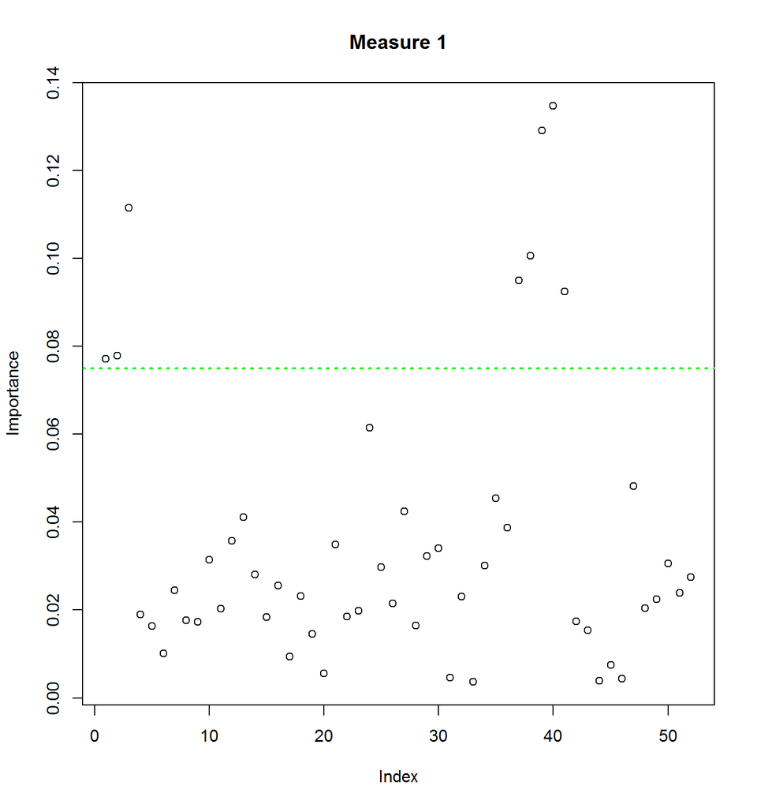

```
## [1] "roll_belt"         "pitch_belt"        "yaw_belt"
## [4] "magnet_dumbbell_x" "magnet_dumbbell_y" "magnet_dumbbell_z"
## [7] "roll_forearm"      "pitch_forearm"
```

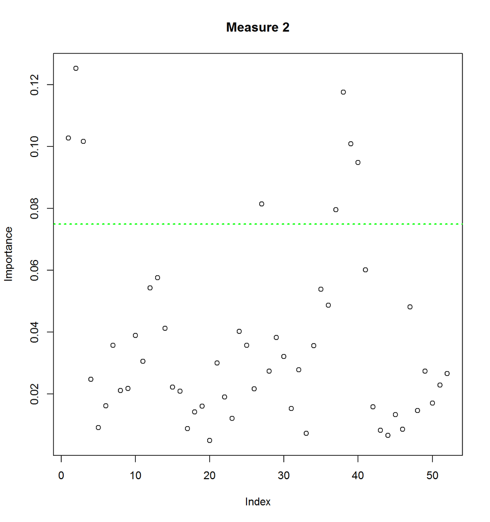

```
## [1] "roll_belt"         "pitch_belt"        "yaw_belt"
## [4] "roll_dumbbell"     "magnet_dumbbell_x" "magnet_dumbbell_y"
## [7] "magnet_dumbbell_z" "roll_forearm"
```

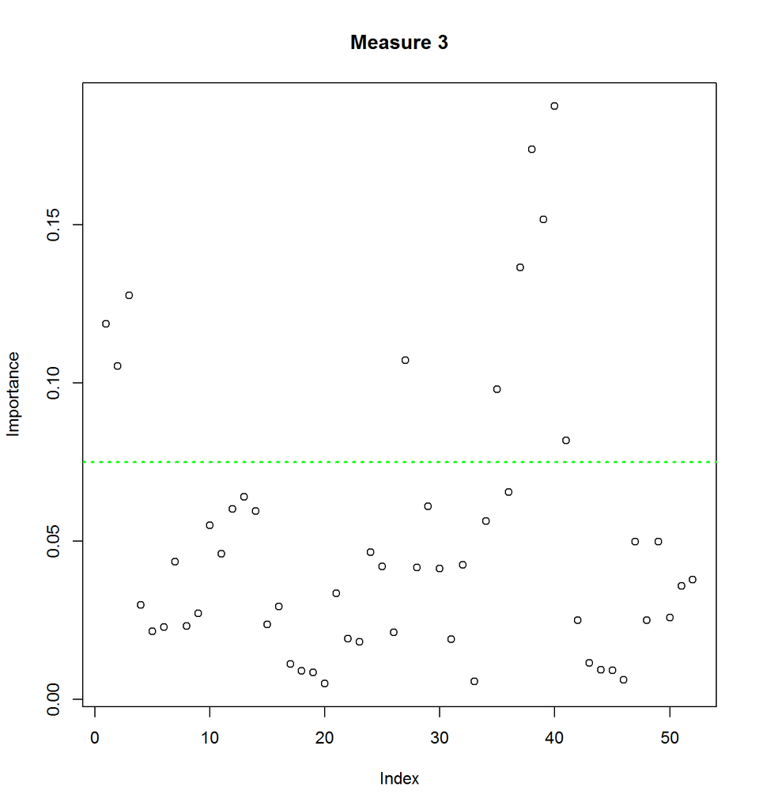

```
##  [1] "roll_belt"         "pitch_belt"        "yaw_belt"
##  [4] "roll_dumbbell"     "accel_dumbbell_y"  "magnet_dumbbell_x"
##  [7] "magnet_dumbbell_y" "magnet_dumbbell_z" "roll_forearm"
## [10] "pitch_forearm"
```

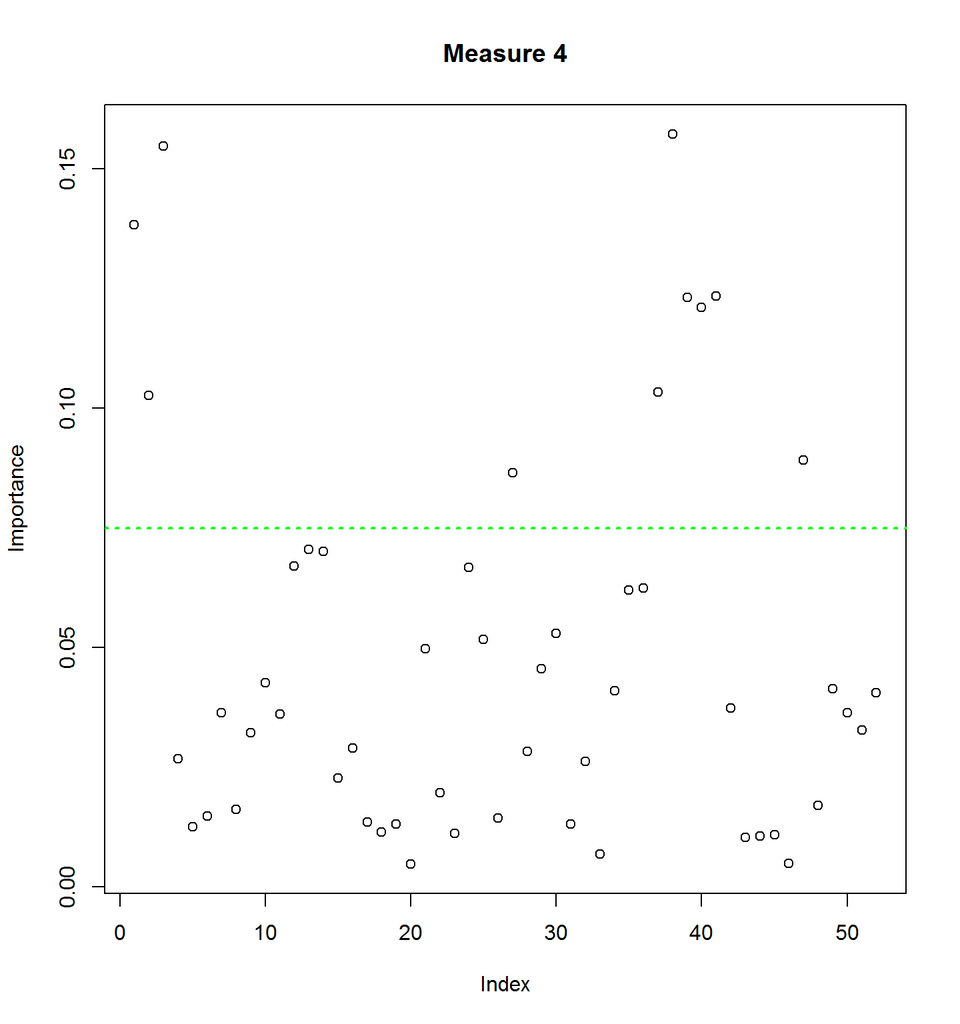

```
##  [1] "roll_belt"         "pitch_belt"        "yaw_belt"
##  [4] "roll_dumbbell"     "magnet_dumbbell_x" "magnet_dumbbell_y"
##  [7] "magnet_dumbbell_z" "roll_forearm"      "pitch_forearm"
## [10] "accel_forearm_x"
```

```r
importants <- c()
for (i in 1:4){
        #print(str(modelFit$importance[,i]))
        x <- sort(modelFit$importance[,i], dec = TRUE)
        #print(x)
        y=modelFit$importance[,i]
        #plot(x, main = paste("Measure in Decreasing Order", i), ylab="Importance")
        #plot(x[1:10], type = "h", main=paste("Measure",i, "Of the top 10"), ylab = "Importance")
        plot(y, main = paste("Measure", i), ylab="Importance")
        abline(h=0.075,col="green",lty=3, lwd = 2)
        importants <- c(importants, names(y[y>.075]))
        print(names(y[y>.075]))
}
```

```r
sort(importants, dec = TRUE)
```

```
##  [1] "yaw_belt"          "yaw_belt"          "yaw_belt"
##  [4] "yaw_belt"          "roll_forearm"      "roll_forearm"
##  [7] "roll_forearm"      "roll_forearm"      "roll_dumbbell"
## [10] "roll_dumbbell"     "roll_dumbbell"     "roll_belt"
## [13] "roll_belt"         "roll_belt"         "roll_belt"
## [16] "pitch_forearm"     "pitch_forearm"     "pitch_forearm"
## [19] "pitch_belt"        "pitch_belt"        "pitch_belt"
## [22] "pitch_belt"        "magnet_dumbbell_z" "magnet_dumbbell_z"
## [25] "magnet_dumbbell_z" "magnet_dumbbell_z" "magnet_dumbbell_y"
## [28] "magnet_dumbbell_y" "magnet_dumbbell_y" "magnet_dumbbell_y"
## [31] "magnet_dumbbell_x" "magnet_dumbbell_x" "magnet_dumbbell_x"
## [34] "magnet_dumbbell_x" "accel_forearm_x"   "accel_dumbbell_y"
```

```r
importants<-unique(importants)
importants
```

```
##  [1] "roll_belt"         "pitch_belt"        "yaw_belt"
##  [4] "magnet_dumbbell_x" "magnet_dumbbell_y" "magnet_dumbbell_z"
##  [7] "roll_forearm"      "pitch_forearm"     "roll_dumbbell"
## [10] "accel_dumbbell_y"  "accel_forearm_x"
```

So, let’s fit a model using only the “important” predictors and guestimate its accuracy by trying it out on the test set.

```r
smallerModelFit <-randomForest(classe ~ roll_belt + pitch_belt + yaw_belt +
                magnet_dumbbell_x+magnet_dumbbell_y+magnet_dumbbell_z
                + roll_forearm + pitch_forearm + roll_dumbbell +
                 accel_dumbbell_y + accel_forearm_x,
                               data = trainingSet, importance = TRUE)
print(smallerModelFit)
```

```
##
## Call:
##  randomForest(formula = classe ~ roll_belt + pitch_belt + yaw_belt +      magnet_dumbbell_x + magnet_dumbbell_y + magnet_dumbbell_z +      roll_forearm + pitch_forearm + roll_dumbbell + accel_dumbbell_y +      accel_forearm_x, data = trainingSet, importance = TRUE)
##                Type of random forest: classification
##                      Number of trees: 500
## No. of variables tried at each split: 3
##
##         OOB estimate of  error rate: 1.07%
## Confusion matrix:
##      A    B    C    D    E class.error
## A 4170   12    2    1    0 0.003584229
## B   21 2777   47    3    0 0.024929775
## C    1   17 2539   10    0 0.010907674
## D    1    4   16 2390    1 0.009121061
## E    0    8    6    8 2684 0.008130081
```

```r
smallerPrediction <- predict(smallerModelFit, testingSet)
testingSet$smallerRightPred <- smallerPrediction == testingSet$classe
t<-table(smallerPrediction, testingSet$classe)
t
```

```
##
## smallerPrediction    A    B    C    D    E
##                 A 1385    7    1    0    0
##                 B    8  933    4    0    2
##                 C    2    7  848    6    3
##                 D    0    2    2  797    8
##                 E    0    0    0    1  888
```

```r
accuracy <- sum(testingSet$smallerRightPred)/nrow(testingSet)
accuracy
```

```
## [1] 0.9891925
```

Hmmm, would a single decision tree work just as well as using random forests? Let’s see!

### Decision Trees

```r
library(rpart)
set.seed(1976)
treeModel <- rpart(classe ~ roll_belt + pitch_belt + yaw_belt +magnet_dumbbell_x
                   +magnet_dumbbell_y+magnet_dumbbell_z + roll_forearm +
                pitch_forearm + roll_dumbbell + accel_dumbbell_y + accel_forearm_x,
                   method="class", data=trainingSet)

printcp(treeModel) # display the results
```

```
##
## Classification tree:
## rpart(formula = classe ~ roll_belt + pitch_belt + yaw_belt +
##     magnet_dumbbell_x + magnet_dumbbell_y + magnet_dumbbell_z +
##     roll_forearm + pitch_forearm + roll_dumbbell + accel_dumbbell_y +
##     accel_forearm_x, data = trainingSet, method = "class")
##
## Variables actually used in tree construction:
## [1] accel_dumbbell_y  accel_forearm_x   magnet_dumbbell_y magnet_dumbbell_z
## [5] pitch_belt        pitch_forearm     roll_belt         roll_forearm
## [9] yaw_belt
##
## Root node error: 10533/14718 = 0.71565
##
## n= 14718
##
##          CP nsplit rel error  xerror      xstd
## 1  0.116871      0   1.00000 1.00000 0.0051957
## 2  0.049559      1   0.88313 0.88313 0.0055546
## 3  0.039400      4   0.72211 0.71585 0.0057572
## 4  0.031710      5   0.68271 0.68214 0.0057573
## 5  0.025824      6   0.65100 0.65888 0.0057496
## 6  0.021884      7   0.62518 0.63277 0.0057333
## 7  0.019463     12   0.50555 0.51429 0.0055548
## 8  0.019273     13   0.48609 0.49530 0.0055096
## 9  0.014336     14   0.46682 0.46948 0.0054403
## 10 0.011583     15   0.45248 0.45514 0.0053978
## 11 0.010348     16   0.44090 0.43948 0.0053480
## 12 0.010000     17   0.43055 0.42837 0.0053105
```

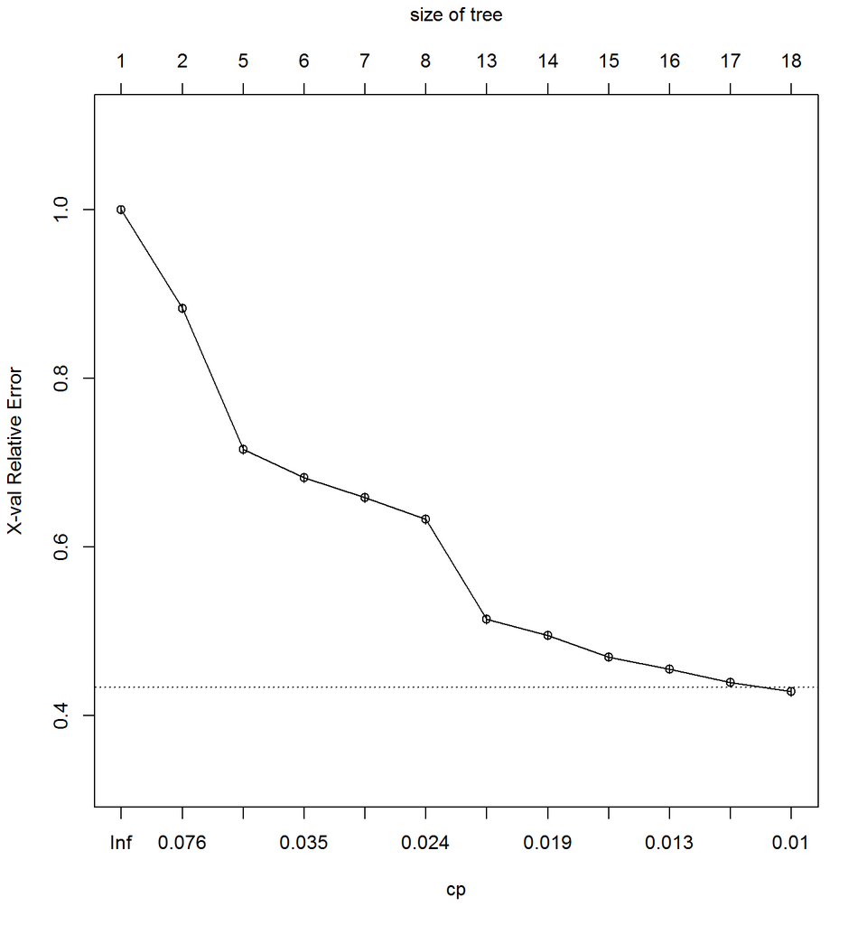

```r
plotcp(treeModel) # visualize cross-validation results
```

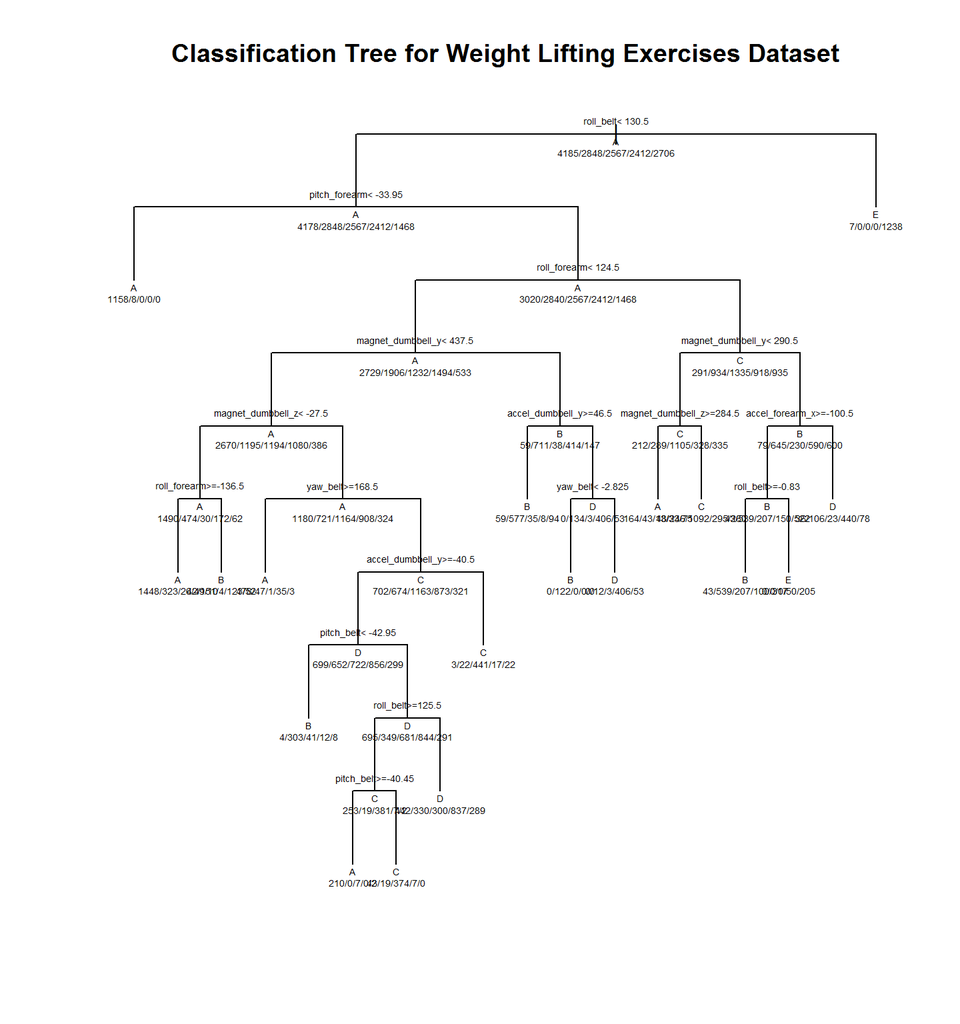

```r
#summary(treeModel) # detailed summary of splits
# plot tree
plot(treeModel, uniform=TRUE,
     main="Classification Tree for Weight Lifting Exercises Dataset")
text(treeModel, use.n=TRUE, all=TRUE, cex=.45)
```

```r
treePredValues <- predict(treeModel, testingSet)
treePrediction <- c()
for (k in 1:nrow(testingSet)) {
        treePrediction <- c(treePrediction, names(which.max(treePredValues[k,])))
}
testingSet$treeRightPred <-treePrediction == testingSet$classe
t<-table(treePrediction, testingSet$classe)
t
```

```
##
## treePrediction    A    B    C    D    E
##              A 1129  134   20   42   29
##              B   64  573   91   75  171
##              C   39  101  665  114   78
##              D  156  141   79  553  157
##              E    7    0    0   20  466
```

```r
accuracy <- sum(testingSet$treeRightPred)/nrow(testingSet)
accuracy
```

```
## [1] 0.6904568
```